# National Reformatory Death Tracker Data Analysis

Tiasia Saunders

2026-05-29

### About this dataset:

#### Column Definitions:

- Facility Type - column that associates the facility with its type, each row only allows for one entry, so (one facility = one type), there is NO overlap
  - Reformatory - an institution to which youthful offenders are sent as an alternative to prison, designed to rehabilitate young or first-time offenders through education, vocational training, and discipline, rather than solely punishing them
  - Correctional - secure, residential institution designed for the custody, rehabilitation, and education of youth under the age of 18 who have been adjudicated delinquent or are awaiting court hearings
  - Industrial School - an educational institution (often residential) that provides vocational training in trades and manual labor, focused on rehabilitating neglected, destitute, or delinquent youth by teaching them practical skills for industrial employment
  - Unknown - not sure what type of facility it is, or there is not enough information to determine the type
- Race
  - Black youth
  - White youth
  - Native American youth
  - All races
  - All races, but segregated
- Deaths: There is evidence that points to 1 or more deaths of incarcerated youth on and connected to the facility. We believe the evidence – from open-sources including Find a Grave, facility records, news articles and state or historical sites is credible enough to report. In instances where there is a discrepancy in the number of deaths, we provide additional information on how we chose the most authoritative number via the “death qualifiers” column.
- Death Qualifiers
  - Any necessary note/comment on the death count number will usually identify the source or any discrepancy in numbers between two different sources. Lastly, if there is a number discrepancy, there will be a brief explanation of why we chose one of the two numbers.
  - On Find a Grave - If it says that the cemetery can hold a certain amount, but the memorial number is different or smaller, go with that number
- Cemetery
  - Yes: There is evidence via open-sources including Find a Grave, facility records, news articles and state or historical sites that support the burial of incarcerated youth at the institution and the existence of a physical cemetery connected to the institution.
  - No: There has not yet been found evidence that supports the existence of a physical cemetery connected to the institution. It does not preclude a cemetery’s existence, but that evidence has not yet been found via a longer, exhaustive investigation.
  - Rumored: Social media sites, blogs or other community-based sites have discussed a physical cemetery location.
  - Possible: The existence of a cemetery is supported by evidence such as death records of incarcerated youth which list the institution as the burial ground, but visual, online evidence of the cemetery has not yet been found. It does not preclude a cemetery’s existence, but that evidence has not yet been found via a longer, exhaustive investigation. We distinguish possible vs. yes on the basis of one or more visual, online markers that point to the existence of a burial site (i.e. cinder blocks).
- State of the cemetery
  - Abandoned: no ownership of the facility or state, left overgrown to withstand natural elements without any maintenance or protection
  - Maintained: ownership of the facility or state to the point where it is regularly cleaned and taken care of
  - If fields are maintained, put in notes who is responsible for doing that
  - We are using this column to help us ‘measure’ several other cemeteries being unrecognized within the nation’s history.
  - Unknown: Don’t know whether there is a cemetery located at this facility. If there is, we are not aware of its condition.
- Reported on Recently
  - Has the topic or facility been substantively reported on via news sites in the past 5-6 years, so since 2020 – based on our time-limited search for specific information, primarily under the facility’s earlier name(s), we did or did not come across recent reporting.
- Allegations of Abuse/ Forced Labor
  - A column that is a select option of yes, no or unknown in regards to whether the facility faced allegations of abuse/ forced labor through historical records and reports. “No” or “Unknown” does not preclude the possibility of abuse or forced labor, but that a longer, exhaustive search has not been conducted to fully answer the question.
- Notes
  - Add links to references and sources of the general information about the facility
  - Any additional information about the facility or the gravesite location at the facility
- Purpose:
  - To be able to make the national case for Cheltenham, by looking at other reformatories with abandoned cemeteries and the death counts. Be able to make the argument of how – via a time-limited, online open-source investigation – this was a national trend, and showcase how many other ‘x’ amount of unrecognized boys or children are in ‘x’ amount of unmarked graves in the country.
  - To be able to get a more cohesive breakdown of the racial demographic, facility type, and additional fields of these facilities, with the abandoned cemeteries and ‘x’ amount of burial deaths in that gravesite.

```r
## loading libraries
library(tidyverse)
library(dplyr)
library(stringr)
library(knitr)
library(readxl)
library(janitor)
```

```r
library(lubridate)
library(ggplot2)
library(tidygeocoder)
```

```r
### loading data

national_death_tracker <- read_csv("new_national_clean.csv") |>
  clean_names()
```

### Getting Lat + Long for Map Data

```r
national_death_tracker$city_state <- gsub("([A-Za-z ]) ([A-Z]{2})$", "\\1, \\2", national_death_tracker$city_state)
```

```r
library(dplyr)
library(stringr)
library(tidygeocoder)

national_clean <- national_death_tracker |>
  mutate(
    city_state = str_trim(city_state),
    city_state = str_remove_all(city_state, '"'),
    city_state = str_remove(city_state, "\\s*\\(.*\\)"),
    city_state = na_if(city_state, ""),

    # fix common misspellings / problem entries
    city_state = str_replace_all(city_state, fixed("Masachusettes"), "Massachusetts"),
    city_state = str_replace_all(city_state, fixed("Massachussetts"), "Massachusetts"),
    city_state = str_replace_all(city_state, fixed("Cincinatti"), "Cincinnati"),
    city_state = str_replace_all(city_state, fixed("Gainsville"), "Gainesville"),
    city_state = str_replace_all(city_state, fixed("Milest City"), "Miles City"),
    city_state = str_replace_all(city_state, fixed("Washington, D.C."), "Washington, DC"),
    city_state = str_replace_all(city_state, fixed("O'ahu, Hawaii"), "Oahu, Hawaii"),

    # flag rows that are only a state and not city + state
    state_only = !str_detect(city_state, ",")
  )
```

```r
national_clean$city_state <- gsub("\\s*\\(.*?\\)", "", national_clean$city_state)
```

```r
national_clean$city_state <- trimws(national_clean$city_state)
```

```r
national_geo <- national_clean |>
  mutate(full_location = paste(name_of_facility, city_state, sep = ", ")) |>
  geocode(full_location, method = "osm", lat = latitude, long = longitude)
```

```
## Passing 91 addresses to the Nominatim single address geocoder
```

```
## Query completed in: 92.1 seconds
```

```r
national_geo_data <- national_death_tracker |>
  mutate(location = paste(city, state, sep = ", ")) |>
  geocode(location, method = "osm", lat = latitude, long = longitude)
```

```
## Passing 88 addresses to the Nominatim single address geocoder
```

```
## Query completed in: 151.3 seconds
```

```r
### cleaning up deaths column
national_death_tracker <- national_death_tracker |>
  mutate(deaths_clean = str_extract(deaths_na, "\\d+"),
         deaths_clean = as.numeric(deaths_clean))
```

#### Preliminary Data Analysis

##### Breakdown of facility type

```r
facility_type_count <- national_death_tracker |>
  count(facility_type) |>
  arrange(desc(n))
```

```r
write.csv(facility_type_count, "facility_type_count.csv", row.names = FALSE)
```

```r
write.csv(national_clean, "national_clean.csv", row.names = FALSE)
```

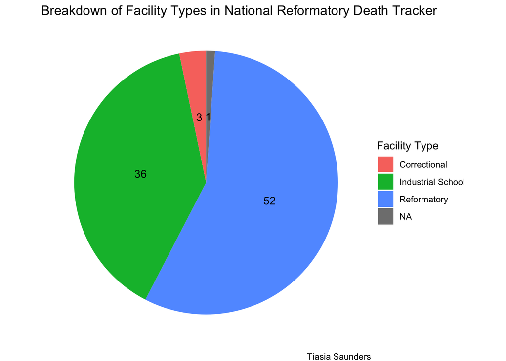

```r
## creating pie chart of facility type breakdwon
ggplot(facility_type_count, aes(x = "", y = n, fill = facility_type)) +
  geom_bar(stat = "identity", width = 1) +

   geom_text(aes(label = n),
            position = position_stack(vjust = 0.5)) +
  coord_polar(theta = "y") +
  labs(title = "Breakdown of Facility Types in National Reformatory Death Tracker", caption = "Tiasia Saunders",
       fill = "Facility Type") +
    theme(plot.caption = element_text(hjust = 1)) +
  theme_void() +
  theme(legend.position = "right")
```

##### We have 52 reformatories, 36 industrial schools, and 3 correctional facilities in our dataset.

##### Gender Count Breakdown

```r
gender_count <- national_death_tracker |>
  count(gender) |>
  arrange(desc(n))
```

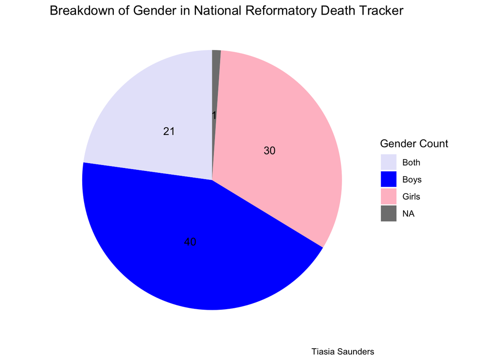

```r
 ggplot(gender_count, aes(x = "", y = n, fill = gender)) +
  geom_bar(stat = "identity", width = 1) +
  coord_polar(theta = "y") +

  geom_text(aes(label = n),
            position = position_stack(vjust = 0.5)) +

  labs(
    title = "Breakdown of Gender in National Reformatory Death Tracker",
    caption = "Tiasia Saunders",
    fill = "Gender Count"
  ) +
  scale_fill_manual(values = c(
    "Boys" = "blue",
    "Girls" = "pink",
    "Both" = "lavender"
  )) +
  theme(plot.caption = element_text(hjust = 1)) +
  theme_void() +
  theme(legend.position = "right")
```

##### We have 40 boys facilities, 30 girls facilities, and 21 both genders facilities.

##### Race Count Breakdown

```r
race_count <- national_death_tracker |>
  count(race) |>
  arrange(desc(n))
```

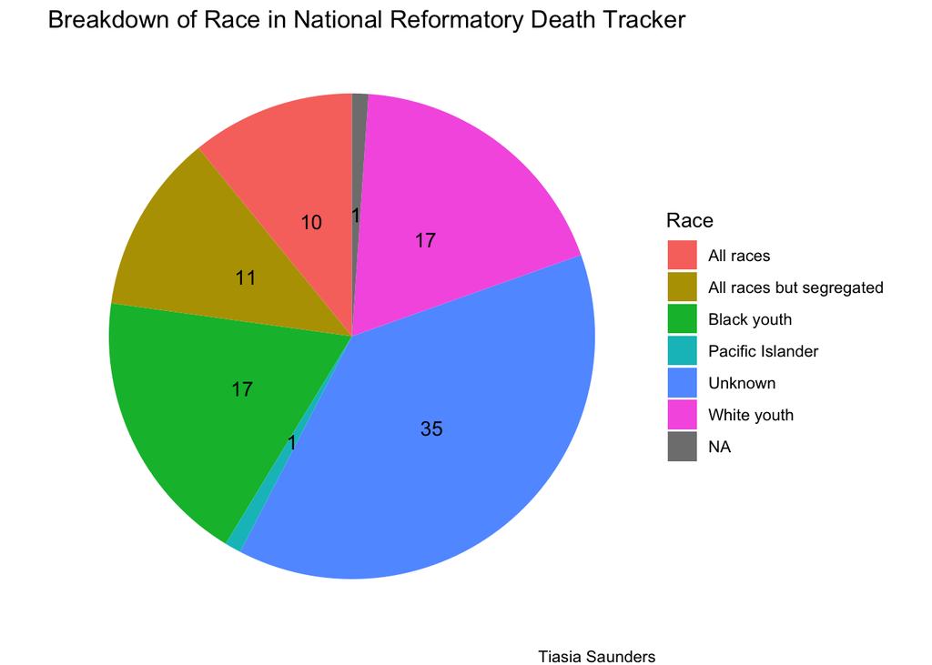

```r
ggplot(race_count, aes(x = "", y = n, fill = race)) +
  geom_bar(stat = "identity", width = 1) +

   geom_text(aes(label = n),
            position = position_stack(vjust = 0.5)) +
  coord_polar(theta = "y") +
  labs(title = "Breakdown of Race in National Reformatory Death Tracker", caption = "Tiasia Saunders",
       fill = "Race") +
    theme(plot.caption = element_text(hjust = 1)) +
  theme_void() +
  theme(legend.position = "right")
```

##### We have 17 white facilities, 17 black facilities, 11 facilities with all races but segregated, and 10 facilities with both white and black races.

##### Cemetery Count Breakdown

```r
cemetery_count <- national_death_tracker |>
  count(cemetery) |>
  arrange(desc(n))
```

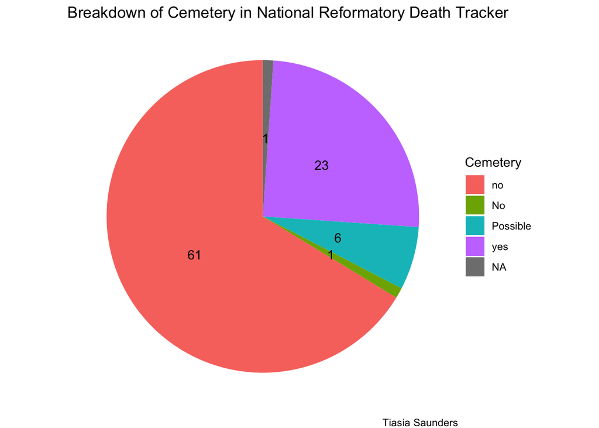

```r
ggplot(cemetery_count, aes(x = "", y = n, fill = cemetery)) +
  geom_bar(stat = "identity", width = 1) +

   geom_text(aes(label = n),
            position = position_stack(vjust = 0.5)) +
  coord_polar(theta = "y") +
  labs(title = "Breakdown of Cemetery in National Reformatory Death Tracker", caption = "Tiasia Saunders",
       fill = "Cemetery") +
    theme(plot.caption = element_text(hjust = 1)) +
  theme_void() +
  theme(legend.position = "right")
```

#### We have 23 facilities with cemeteries, 62 without cemteries, and 6 to be possible.

##### State of Cemetery Breakdown

```r
state_of_cemetery_breakdown <- national_death_tracker |>
  count(state_of_cemetery) |>
  arrange(desc(n))
```

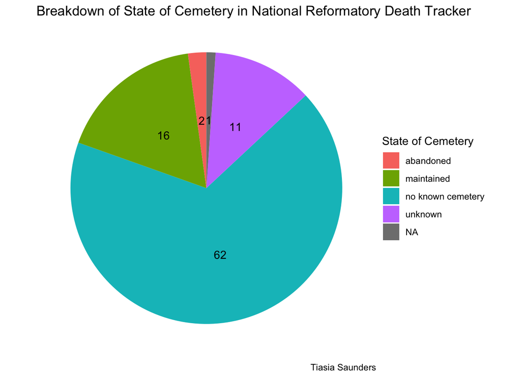

```r
ggplot(state_of_cemetery_breakdown, aes(x = "", y = n, fill = state_of_cemetery)) +
  geom_bar(stat = "identity", width = 1) +

   geom_text(aes(label = n),
            position = position_stack(vjust = 0.5)) +
  coord_polar(theta = "y") +
  labs(title = "Breakdown of State of Cemetery in National Reformatory Death Tracker", caption = "Tiasia Saunders",
       fill = "State of Cemetery") +
    theme(plot.caption = element_text(hjust = 1)) +
  theme_void() +
  theme(legend.position = "right")
```

##### Out of the cemeteries breakdown, we have 16 cemeteries that are maintained and we have 2 that were abandoned.

##### Abandonded Cemeteries Death Count

```r
## counting the number of deaths for abandoned cemeteries
abandoned_cemetery_count <- national_death_tracker |>
  filter(state_of_cemetery == "abandoned") |>
  summarise(total_deaths = sum(deaths_clean, na.rm = TRUE))
```

##### So, we have 243 deaths that are associated with abandoned cemeteries. Out of those, 243 is from the Cheltenham Reformatory.

##### Abandoned Cemeteries Breakdown

```r
abandoned_cemteries <- national_death_tracker |>
  filter(state_of_cemetery == "abandoned") |>
  select(name_of_facility, facility_type, race, city_state, gender, allegations_of_abuse, years_of_existence, death_qualifiers, reported_on_recently, allegations_of_forced_labor, deaths_clean)

write.csv(abandoned_cemteries, "abandoned_cemeteries.csv", row.names = FALSE)
```

- We have 2 abandoned (technical 1 since we arleady knew about Cheltenham) facilities
- The facilities are the following: House of Reformation and Instruction for Colored Boys (Reformatory) and the VA Industrial School for Colored Girls (Industrial School)
- These facilities were established to house juvenile Black boys (Cheletenham) and housed juvenile Black girls (VA Industrial)
- They both had allegations of abuse and forced labor
- 1 out of two was reported on recently (Cheltenham whereas the VA Industrial School has not been reported on recently)
- The death counts are the following: 243 = Cheltenham and VA Industrial = 0

##### Reported on Recently Breakdown

```r
reported_recently_count <- national_death_tracker |>
 count(reported_on_recently) |>
  arrange(desc(n))

reported_recently_count
```

```
## # A tibble: 3 × 2
##   reported_on_recently     n
##   <chr>                <int>
## 1 no                      66
## 2 yes                     25
## 3 <NA>                     1
```

##### Most of our data has not been reported on recently (66), we are looking at whether it was reported on in the last five years.

##### Abuse/Forced Allegations Breakdown

```r
abuse_allegations_count <- national_death_tracker |>
  count(allegations_of_abuse) |>
  arrange(desc(n))

forced_labor_count <- national_death_tracker |>
  count(allegations_of_forced_labor) |>
  arrange(desc(n))
```

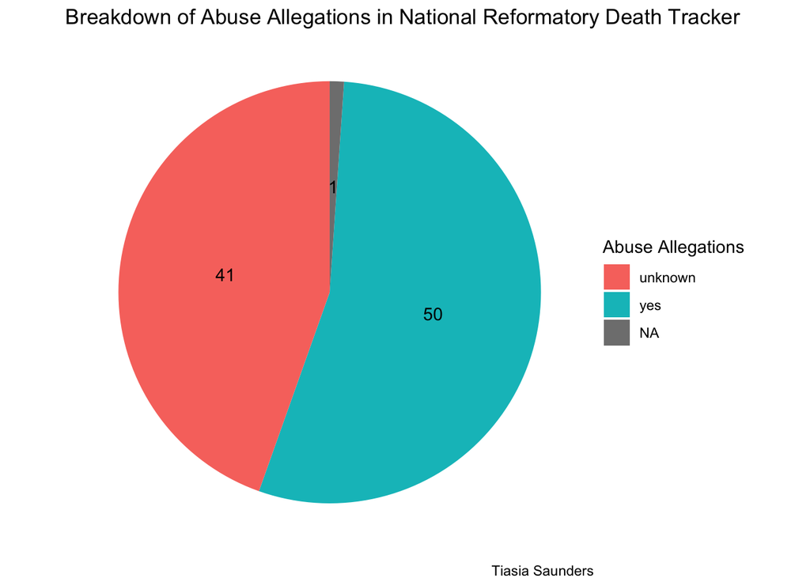

```r
ggplot(abuse_allegations_count, aes(x = "", y = n, fill = allegations_of_abuse)) +
  geom_bar(stat = "identity", width = 1) +

   geom_text(aes(label = n),
            position = position_stack(vjust = 0.5)) +
  coord_polar(theta = "y") +
  labs(title = "Breakdown of Abuse Allegations in National Reformatory Death Tracker", caption = "Tiasia Saunders",
       fill = "Abuse Allegations") +
    theme(plot.caption = element_text(hjust = 1)) +
  theme_void() +
  theme(legend.position = "right")
```

##### We have 50 facilities with allegations of abuse and 41 unknown with 1 being NA.

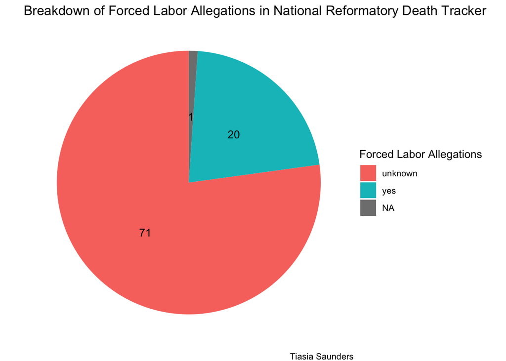

```r
ggplot(forced_labor_count, aes(x = "", y = n, fill = allegations_of_forced_labor)) +
  geom_bar(stat = "identity", width = 1) +

   geom_text(aes(label = n),
            position = position_stack(vjust = 0.5)) +
  coord_polar(theta = "y") +
  labs(title = "Breakdown of Forced Labor Allegations in National Reformatory Death Tracker", caption = "Tiasia Saunders",
       fill = "Forced Labor Allegations") +
    theme(plot.caption = element_text(hjust = 1)) +
  theme_void() +
  theme(legend.position = "right")
```

##### We have 20 facilities with allegations of forced labor, 71 unknown, and 1 with NA

##### Death Count Total

```r
national_death_tracker <- national_death_tracker |>
  mutate(deaths_clean = str_extract(deaths_na, "\\d+"),
         deaths_clean = as.numeric(deaths_clean))
  total_deaths <- sum(national_death_tracker$deaths_clean, na.rm = TRUE)
  total_deaths
```

```
## [1] 1996
```

```r
looking_at_death_counts <- national_death_tracker |>
  select(deaths_na, deaths_clean, death_qualifiers)
```